# MD6

Author

Wayne Frederick II

```r
library(broom)
library(tidyverse)
library(moderndive)
library(dplyr)
library(patchwork)
library(ggthemes)
# Set our ggplot theme from the outset
theme_set(theme_light())
# Read in the data
gender_employment <- read_csv("https://raw.githubusercontent.com/vaiseys/dav-course/main/Data/gender_employment.csv")
# Glimpse at the data
glimpse(gender_employment)
```

```
Rows: 2,088
Columns: 12
$ year                  <dbl> 2013, 2013, 2013, 2013, 2013, 2013, 2013, 2013, …
$ occupation            <chr> "Chief executives", "General and operations mana…
$ major_category        <chr> "Management, Business, and Financial", "Manageme…
$ minor_category        <chr> "Management", "Management", "Management", "Manag…
$ total_workers         <dbl> 1024259, 977284, 14815, 43015, 754514, 44198, 10…
$ workers_male          <dbl> 782400, 681627, 8375, 17775, 440078, 16141, 7287…
$ workers_female        <dbl> 241859, 295657, 6440, 25240, 314436, 28057, 3683…
$ percent_female        <dbl> 23.6, 30.3, 43.5, 58.7, 41.7, 63.5, 33.6, 27.5, …
$ total_earnings        <dbl> 120254, 73557, 67155, 61371, 78455, 74114, 62187…
$ total_earnings_male   <dbl> 126142, 81041, 71530, 75190, 91998, 90071, 66579…
$ total_earnings_female <dbl> 95921, 60759, 65325, 55860, 65040, 66052, 55079,…
$ wage_percent_of_male  <dbl> 76.04208, 74.97316, 91.32532, 74.29179, 70.69719…
```

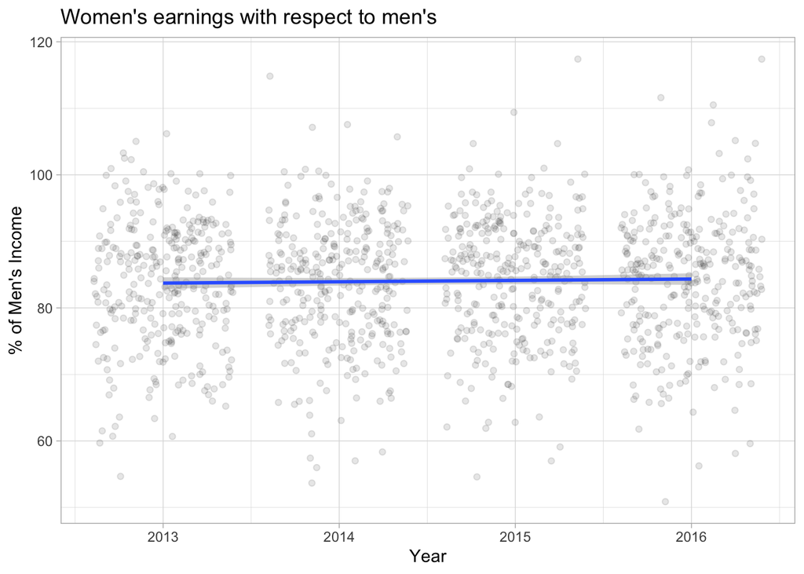

```r
gender_employment%>%
  ggplot(aes(x = year, y = wage_percent_of_male)) +
  geom_jitter(alpha = 0.1) +
  geom_smooth(method = "lm") +
  labs(title = "Women's earnings with respect to men's",
       y = "% of Men's Income",
       x = "Year")
```

## Question 1

```r
gender_employment <- gender_employment %>%
  mutate(major_category = as.factor(major_category),
         major_category = relevel(major_category, ref = "Management, Business, and Financial"))
```

```r
parallel_model <- lm(wage_percent_of_male ~ year + major_category,
                     data = gender_employment)
broom::tidy(parallel_model)
```

```
# A tibble: 9 × 5
  term                                     estimate std.error statistic  p.value
  <chr>                                       <dbl>     <dbl>     <dbl>    <dbl>
1 (Intercept)                              -307.      459.       -0.669 5.04e- 1
2 year                                        0.192     0.228     0.844 3.99e- 1
3 major_categoryComputer, Engineering, an…    6.32      0.946     6.68  3.56e-11
4 major_categoryEducation, Legal, Communi…    5.76      0.985     5.84  6.53e- 9
5 major_categoryHealthcare Practitioners …    5.52      1.10      5.00  6.41e- 7
6 major_categoryNatural Resources, Constr…    4.91      1.24      3.95  8.15e- 5
7 major_categoryProduction, Transportatio…   -1.31      0.960    -1.37  1.72e- 1
8 major_categorySales and Office              3.33      0.858     3.88  1.11e- 4
9 major_categoryService                       6.08      0.885     6.87  1.03e-11
```

```r
-306.7184+ 0.1922*2015+3.3261
```

```
[1] 83.8907
```

Sales and Office occupations had 83.9% of male income in 2015.

```r
-306.7184+ 0.1922*2016+ 5.7563
```

```
[1] 86.5131
```

## Question 2

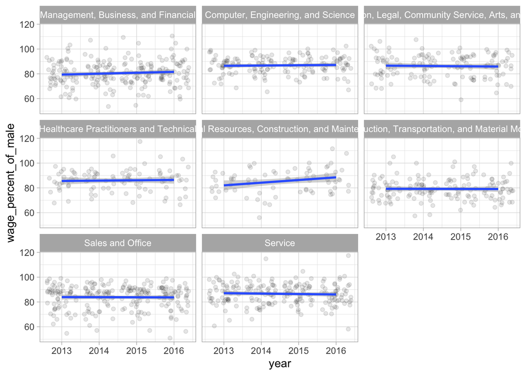

```r
gender_employment %>%
  ggplot(aes(x = year, y = wage_percent_of_male)) +
  geom_jitter(alpha = 0.1) +
  geom_smooth(method = "lm") + facet_wrap(~major_category)
```

```r
  labs(title = "Women's earnings with respect to men's",
       y = "% of Men's Income",
       x = "Year")
```

```
$y
[1] "% of Men's Income"

$x
[1] "Year"

$title
[1] "Women's earnings with respect to men's"

attr(,"class")
[1] "labels"
```

Their is a lot of difference in the wage percent of male across the categories so we cannot use the parallel trends assumption.

## Question 3

```r
interactionmodel <- lm(wage_percent_of_male ~ year*major_category, data = gender_employment)

broom::tidy(interactionmodel)
```

```
# A tibble: 16 × 5
   term                                     estimate std.error statistic p.value
   <chr>                                       <dbl>     <dbl>     <dbl>   <dbl>
 1 (Intercept)                              -1.37e+3  1106.       -1.24    0.216
 2 year                                      7.20e-1     0.549     1.31    0.190
 3 major_categoryComputer, Engineering, an…  1.00e+3  1703.        0.589   0.556
 4 major_categoryEducation, Legal, Communi…  1.94e+3  1774.        1.09    0.275
 5 major_categoryHealthcare Practitioners …  9.06e+2  1987.        0.456   0.649
 6 major_categoryNatural Resources, Constr… -2.89e+3  2232.       -1.29    0.196
 7 major_categoryProduction, Transportatio…  1.58e+3  1735.        0.909   0.363
 8 major_categorySales and Office            1.61e+3  1541.        1.05    0.296
 9 major_categoryService                     2.14e+3  1595.        1.34    0.180
10 year:major_categoryComputer, Engineerin… -4.95e-1     0.845    -0.585   0.559
11 year:major_categoryEducation, Legal, Co… -9.59e-1     0.880    -1.09    0.276
12 year:major_categoryHealthcare Practitio… -4.47e-1     0.986    -0.453   0.651
13 year:major_categoryNatural Resources, C…  1.44e+0     1.11      1.30    0.195
14 year:major_categoryProduction, Transpor… -7.84e-1     0.861    -0.910   0.363
15 year:major_categorySales and Office      -7.98e-1     0.765    -1.04    0.297
16 year:major_categoryService               -1.06e+0     0.792    -1.34    0.182
```

```r
-1370.4719187 + 0.7202561*2016 + 1002.8532317*1 - 0.4946783*2016*1
```

```
[1] 87.14616
```

Our model shows that the Computer, Engineering, and Science jobs made 87.14% of male income in 2016.

```r
-1370.4719187 + 0.7202561*2016 + 2137.6501474*1 - 1.0581075*2016*1
```

```
[1] 86.06981
```

The model estimates that service jobs made 86.07% of male income. The main difference is that there are more components needed to make this calculation compared to the previous model

## Question 4

We would choose to use a model that assumes parallel trends because it can be useful to have a baseline for the whole data set which will show the relationship well.

## Question 5

```r
simple_fit <- lm(wage_percent_of_male ~ year,
                 data = gender_employment)
broom::tidy(simple_fit)
```

```
# A tibble: 2 × 5
  term        estimate std.error statistic p.value
  <chr>          <dbl>     <dbl>     <dbl>   <dbl>
1 (Intercept) -322.      479.       -0.671   0.502
2 year           0.201     0.238     0.847   0.397
```

For every year the wage percent of male counterparts goes up by 0.2%.

```r
gender_employment %>%
  select(year, wage_percent_of_male, percent_female) %>%
  cor(use = "complete.obs")
```

```
                            year wage_percent_of_male percent_female
year                 1.000000000           0.02403895    0.004998286
wage_percent_of_male 0.024038950           1.00000000    0.111464461
percent_female       0.004998286           0.11146446    1.000000000
```

```r
multiple_fit <- lm(wage_percent_of_male ~ year*percent_female,
                   data = gender_employment)
broom::tidy(multiple_fit)
```

```
# A tibble: 4 × 5
  term                  estimate  std.error statistic p.value
  <chr>                    <dbl>      <dbl>     <dbl>   <dbl>
1 (Intercept)         -800.      1009.         -0.793   0.428
2 year                   0.438      0.501       0.874   0.382
3 percent_female        10.6       19.4         0.548   0.584
4 year:percent_female   -0.00526    0.00963    -0.546   0.585
```

```r
multiple_fit
```

```
Call:
lm(formula = wage_percent_of_male ~ year * percent_female, data = gender_employment)

Coefficients:
        (Intercept)                 year       percent_female
         -8.001e+02            4.379e-01            1.064e+01
year:percent_female
         -5.259e-03
```

## Question 6

```r
simple_glanced <- broom::glance(simple_fit)
simple_glanced$r.squared
```

```
[1] 0.0005778711
```

r^2 explains tells us how much the variation of a dependent variable is explained by the independent variable.

```r
multiple_glanced <- broom::glance(multiple_fit)
multiple_glanced$r.squared
```

```
[1] 0.01321338
```

r^2 is larger in this case so that means more of the variation of the dependent variable is relying on the independent variable hence the larger number.